# Dublin Data Science Workshop on Survival Analysis

Section 1

Mick Cooney mickcooney@gmail.com

Monday, 24 September 2018

# 1 Basic Concepts

In *survival analysis* we analyse *time-to-event* data and try to estimate the underlying distribution of times for events to occur.

## 1.1 Introduction

For the purposes of this workshop, we focus on a single event type, but the topic is wide and broadly applicable.

### 1.1.1 Workshop Materials

All materials for this workshop is available in my standard GitHub repo:

https://github.com/kaybenleroll/dublin_r_workshops

[figure not shown]

book cover

The content of this workshop is partly based on the book “Applied Survival Analysis Using R” by Dirk F. Moore. The data from this book is available from CRAN via the package `asaur` and there is a GitHub repo for the code in the book also:

https://github.com/kolaczyk/sand

### 1.1.2 Example Datasets

This workshop will use a number of different time-to-event datasets, so we look at those first.

#### 1.1.2.1 Telco Churn Data

The telco churn data contains some customer usage information on mobile phone customers and whether or not they left their subscription accounts.

```r
telco_churn_tbl %>% glimpse()
```

```
## Observations: 5,000
## Variables: 21
## $ state            <chr> "KS", "OH", "NJ", "OH", "OK", "AL", "MA", "MO", "L...
## $ accountdur       <int> 128, 107, 137, 84, 75, 118, 121, 147, 117, 141, 65...
## $ areacode         <int> 415, 415, 415, 408, 415, 510, 510, 415, 408, 415, ...
## $ phonenumber      <chr> "382-4657", "371-7191", "358-1921", "375-9999", "3...
## $ intlplan         <chr> "no", "no", "no", "yes", "yes", "yes", "no", "yes"...
## $ vmailplan        <chr> "yes", "yes", "no", "no", "no", "no", "yes", "no",...
## $ vmailmessage     <int> 25, 26, 0, 0, 0, 0, 24, 0, 0, 37, 0, 0, 0, 0, 0, 0...
## $ daymins          <dbl> 265.1, 161.6, 243.4, 299.4, 166.7, 223.4, 218.2, 1...
## $ daycalls         <int> 110, 123, 114, 71, 113, 98, 88, 79, 97, 84, 137, 1...
## $ daycharge        <dbl> 45.07, 27.47, 41.38, 50.90, 28.34, 37.98, 37.09, 2...
## $ evemins          <dbl> 197.4, 195.5, 121.2, 61.9, 148.3, 220.6, 348.5, 10...
## $ evecalls         <int> 99, 103, 110, 88, 122, 101, 108, 94, 80, 111, 83, ...
## $ evecharge        <dbl> 16.78, 16.62, 10.30, 5.26, 12.61, 18.75, 29.62, 8....
## $ nightmins        <dbl> 244.7, 254.4, 162.6, 196.9, 186.9, 203.9, 212.6, 2...
## $ nightcalls       <int> 91, 103, 104, 89, 121, 118, 118, 96, 90, 97, 111, ...
## $ nightcharge      <dbl> 11.01, 11.45, 7.32, 8.86, 8.41, 9.18, 9.57, 9.53, ...
## $ intlmins         <dbl> 10.0, 13.7, 12.2, 6.6, 10.1, 6.3, 7.5, 7.1, 8.7, 1...
## $ intlcalls        <int> 3, 3, 5, 7, 3, 6, 7, 6, 4, 5, 6, 5, 2, 5, 6, 9, 4,...
## $ intlcharge       <dbl> 2.70, 3.70, 3.29, 1.78, 2.73, 1.70, 2.03, 1.92, 2....
## $ custservicecalls <int> 1, 1, 0, 2, 3, 0, 3, 0, 1, 0, 4, 0, 1, 3, 4, 4, 1,...
## $ churned          <lgl> FALSE, FALSE, FALSE, FALSE, FALSE, FALSE, FALSE, F...
```

```r
telco_churn_tbl %>% head()
```

```
## # A tibble: 6 x 21
##   state accountdur areacode phonenumber intlplan vmailplan vmailmessage daymins
##   <chr>      <int>    <int> <chr>       <chr>    <chr>            <int>   <dbl>
## 1 KS           128      415 382-4657    no       yes                 25    265.
## 2 OH           107      415 371-7191    no       yes                 26    162.
## 3 NJ           137      415 358-1921    no       no                   0    243.
## 4 OH            84      408 375-9999    yes      no                   0    299.
## 5 OK            75      415 330-6626    yes      no                   0    167.
## 6 AL           118      510 391-8027    yes      no                   0    223.
## # ... with 13 more variables: daycalls <int>, daycharge <dbl>, evemins <dbl>,
## #   evecalls <int>, evecharge <dbl>, nightmins <dbl>, nightcalls <int>,
## #   nightcharge <dbl>, intlmins <dbl>, intlcalls <int>, intlcharge <dbl>,
## #   custservicecalls <int>, churned <lgl>
```

#### 1.1.2.2 Prostate Survival

The prostate survival data is generated data from a cancer survival study.

```r
prostate_surv_tbl %>% glimpse()
```

```
## Observations: 14,294
## Variables: 5
## $ grade    <fct> mode, mode, poor, mode, mode, poor, poor, mode, mode, poor...
## $ stage    <fct> T1c, T1ab, T1c, T2, T1c, T2, T1c, T1ab, T1c, T2, T1c, T1c,...
## $ ageGroup <fct> 80+, 75-79, 75-79, 70-74, 70-74, 75-79, 80+, 80+, 75-79, 7...
## $ survTime <int> 18, 23, 37, 27, 42, 38, 18, 78, 47, 13, 81, 23, 21, 13, 11...
## $ status   <int> 0, 0, 0, 0, 0, 2, 0, 0, 0, 0, 0, 0, 0, 0, 0, 0, 0, 0, 0, 0...
```

```r
prostate_surv_tbl %>% head()
```

```
## # A tibble: 6 x 5
##   grade stage ageGroup survTime status
##   <fct> <fct> <fct>       <int>  <int>
## 1 mode  T1c   80+            18      0
## 2 mode  T1ab  75-79          23      0
## 3 poor  T1c   75-79          37      0
## 4 mode  T2    70-74          27      0
## 5 mode  T1c   70-74          42      0
## 6 poor  T2    75-79          38      2
```

#### 1.1.2.3 Smoker Data

The smoker data is a smoking relapse study involving a number of different treatments and details on when and if the patient resumed smoking.

```r
pharmaco_smoker_tbl %>% glimpse()
```

```
## Observations: 125
## Variables: 14
## $ id             <int> 21, 113, 39, 80, 87, 29, 16, 35, 54, 70, 84, 85, 25,...
## $ ttr            <int> 182, 14, 5, 16, 0, 182, 14, 77, 2, 0, 12, 182, 21, 3...
## $ relapse        <int> 0, 1, 1, 1, 1, 0, 1, 1, 1, 1, 1, 0, 1, 1, 1, 1, 1, 0...
## $ grp            <fct> patchOnly, patchOnly, combination, combination, comb...
## $ age            <int> 36, 41, 25, 54, 45, 43, 66, 78, 40, 38, 64, 51, 37, ...
## $ gender         <fct> Male, Male, Female, Male, Male, Male, Male, Female, ...
## $ race           <fct> white, white, white, white, white, hispanic, black, ...
## $ employment     <fct> ft, other, other, ft, other, ft, pt, other, ft, ft, ...
## $ yearsSmoking   <int> 26, 27, 12, 39, 30, 30, 54, 56, 25, 23, 30, 35, 23, ...
## $ levelSmoking   <fct> heavy, heavy, heavy, heavy, heavy, heavy, heavy, lig...
## $ ageGroup2      <fct> 21-49, 21-49, 21-49, 50+, 21-49, 21-49, 50+, 50+, 21...
## $ ageGroup4      <fct> 35-49, 35-49, 21-34, 50-64, 35-49, 35-49, 65+, 65+, ...
## $ priorAttempts  <int> 0, 3, 3, 0, 0, 2, 0, 10, 4, 10, 12, 1, 5, 6, 5, 2, 1...
## $ longestNoSmoke <int> 0, 90, 21, 0, 0, 1825, 0, 15, 7, 90, 365, 7, 1095, 1...
```

```r
pharmaco_smoker_tbl %>% head()
```

```
## # A tibble: 6 x 14
##      id   ttr relapse grp     age gender race  employment yearsSmoking
##   <int> <int>   <int> <fct> <int> <fct>  <fct> <fct>             <int>
## 1    21   182       0 patc…    36 Male   white ft                   26
## 2   113    14       1 patc…    41 Male   white other                27
## 3    39     5       1 comb…    25 Female white other                12
## 4    80    16       1 comb…    54 Male   white ft                   39
## 5    87     0       1 comb…    45 Male   white other                30
## 6    29   182       0 comb…    43 Male   hisp… ft                   30
## # ... with 5 more variables: levelSmoking <fct>, ageGroup2 <fct>,
## #   ageGroup4 <fct>, priorAttempts <int>, longestNoSmoke <int>
```

## 1.2 Basic Principles

### 1.2.1 Data Censoring and Truncation

In the problems we work on, our data observation process does not allow us to fully observe the variable in question. Instead, our observations are often *right-censored* - that is, we know the value in question is at least the observed value, but it may also be higher.

Expressing this formally, suppose $T^*$ is the time to event, and $U$ is the time to the censoring, the our observed time $T$, and censoring indicator, $\delta$, are given by

$$\begin{eqnarray*}
T &=& \min(T^*, U) \\
\delta &=& I[T^* \leq U]
\end{eqnarray*}$$

A less common phenomenon is *left-censoring* - where we observe the event to be at most a given duration. This may happen in medical studies where continual observation of the patients is not possible or feasible.

### 1.2.2 Hazard and Survival Functions

Our key goal is to find the survival distribution - the distribution of times from some given start point to the time of the event.

Two common ways of specifying this distribution are the *survival function*, $S(t)$ and the *hazard function*, $h(t)$.

$S(t)$ is the probability of surviving to time $t$, so is defined as follows:

$$S(t) = P(T > t), \, 0 \leq t \leq \infty$$

Thus, $S(0) = 1$ and decreases monotonically with time $t$. As it is a probability it is non-negative.

We can also define the survival function in terms of the instantaneous failure rate, the probability of failing at exactly time $t$. More formally,

$$\lambda(t) = \lim_{\delta \to 0} \frac{P(t \leq T \leq t + \delta \; | \, T > t)}{\delta}$$

This is also called the *intensity function* or the *force of mortality*

### 1.2.3 Cumulative Functions

Some analyses make it easier to use the *cumulative hazard function*

$$\Lambda(t) = \int^t_0 \lambda(u) \, du$$

As a consequence of this definition we also have

$$S(t) = \exp(- \Lambda(t))$$

### 1.2.4 Mean and Median Survival

Finally, two common statistics for survival are the *mean survival time* and the *median survival time*:

The mean survival time is the expected value of the distribution, using standard probability definitions:

$$\mu = E(T) = \int^\infty_0 t f(t) \, dt = \int^\infty_0 S(t) \, dt$$

The median survival time, $t_{\text{med}}$ such that

$$S(t_{\text{med}}) = 0.5$$

## 1.3 Example Distributions

Let’s look at some different survival distributions.

### 1.3.1 Constant Hazard

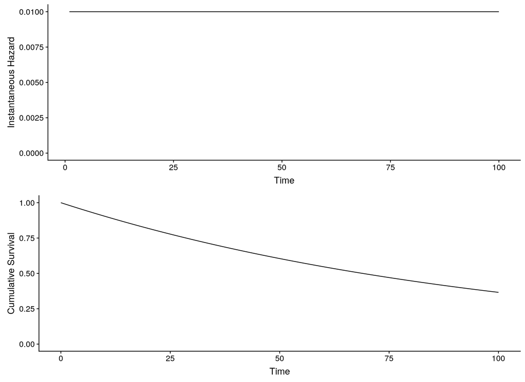

```r
t_seq <- 1:100

h_const_seq <- rep_along(t_seq, 0.01)
S_const_seq <- cumprod(c(1, (1 - h_const_seq)))


hazard_plot <- ggplot() +
    geom_line(aes(x = t_seq, y = h_const_seq)) +
    expand_limits(y = 0) +
    xlab("Time") +
    ylab("Instantaneous Hazard")

cuml_plot <- ggplot() +
    geom_line(aes(x = c(0, t_seq), y = S_const_seq)) +
    expand_limits(y = 0) +
    xlab("Time") +
    ylab("Cumulative Survival")

plot_grid(hazard_plot, cuml_plot, nrow = 2)
```

If we increase the constant hazard, we get a similar shape, but the curve declines faster.

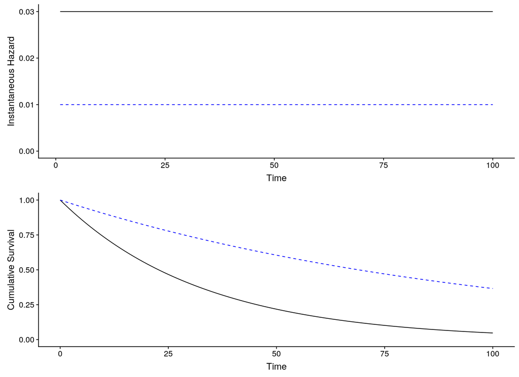

```r
h_const_high_seq <- rep_along(t_seq, 0.03)
S_const_high_seq <- cumprod(c(1, (1 - h_const_high_seq)))


hazard_plot <- ggplot() +
    geom_line(aes(x = t_seq, y = h_const_high_seq)) +
    geom_line(aes(x = t_seq, y = h_const_seq)
             ,colour = 'blue', linetype = 'dashed') +
    expand_limits(y = 0) +
    xlab("Time") +
    ylab("Instantaneous Hazard")

cuml_plot <- ggplot() +
    geom_line(aes(x = c(0, t_seq), y = S_const_high_seq)) +
    geom_line(aes(x = c(0, t_seq), y = S_const_seq)
             ,colour = 'blue', linetype = 'dashed') +
    expand_limits(y = 0) +
    xlab("Time") +
    ylab("Cumulative Survival")

plot_grid(hazard_plot, cuml_plot, nrow = 2)
```

### 1.3.2 Early Hazard

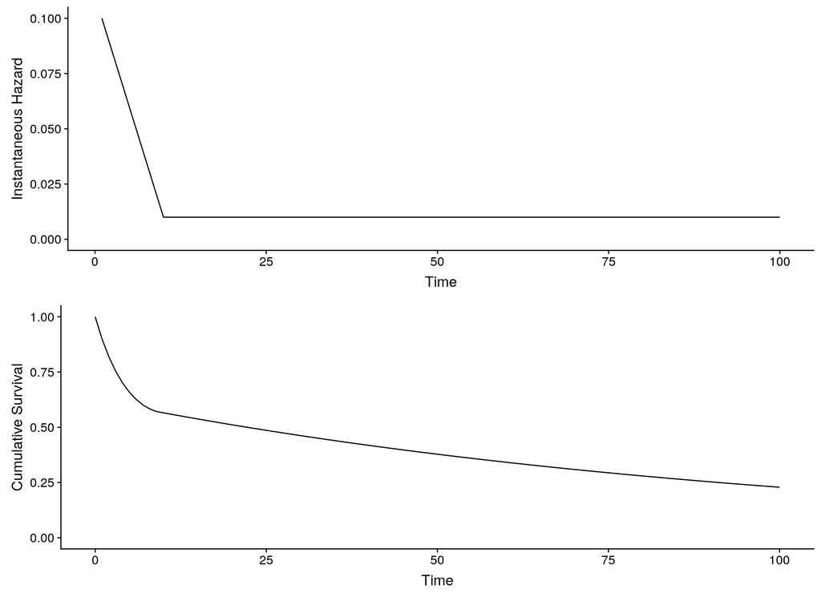

```r
early_seq <- seq(0.10, 0.01, by = -0.01)
late_seq  <- rep(0.01, 100 - length(early_seq))

h_early_seq <- c(early_seq, late_seq)
S_early_seq <- cumprod(c(1, (1 - h_early_seq)))


hazard_plot <- ggplot() +
    geom_line(aes(x = t_seq, y = h_early_seq)) +
    expand_limits(y = 0) +
    xlab("Time") +
    ylab("Instantaneous Hazard")

cuml_plot <- ggplot() +
    geom_line(aes(x = c(0, t_seq), y = S_early_seq)) +
    expand_limits(y = 0) +
    xlab("Time") +
    ylab("Cumulative Survival")

plot_grid(hazard_plot, cuml_plot, nrow = 2)
```

### 1.3.3 Late Hazard

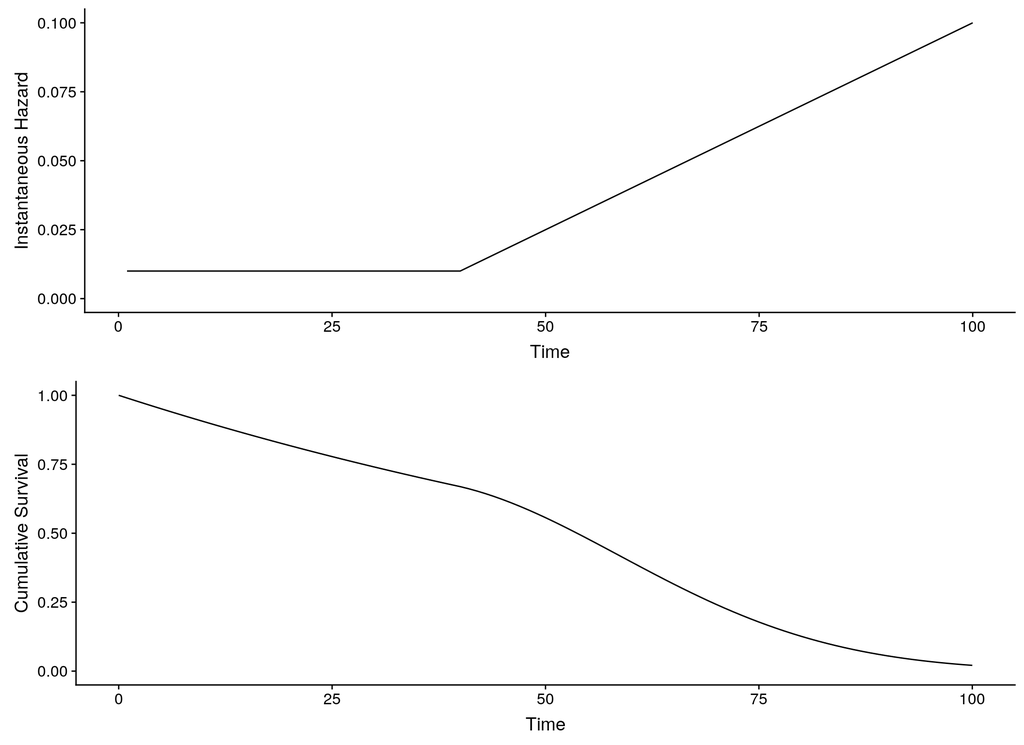

[output not shown]

[output not shown]

[output not shown]

[output cut: 19 more lines]

[output not shown]

```r
late_seq  <- seq(0.01, 0.10, by = 0.0015)
early_seq <- rep(0.01, 100 - length(late_seq))

h_late_seq <- c(early_seq, late_seq)
S_late_seq <- cumprod(c(1, (1 - h_late_seq)))


hazard_plot <- ggplot() +
    geom_line(aes(x = t_seq, y = h_late_seq)) +
    expand_limits(y = 0) +
    xlab("Time") +
    ylab("Instantaneous Hazard")

cuml_plot <- ggplot() +
    geom_line(aes(x = c(0, t_seq), y = S_late_seq)) +
    expand_limits(y = 0) +
    xlab("Time") +
    ylab("Cumulative Survival")

plot_grid(hazard_plot, cuml_plot, nrow = 2)
```